# Formulas and Model Families: mtcars I

Ray Nelson

29 March 2019

## Models

- Extract patterns from data
- Decompose variation into explained and unexplained
- Extract all possible information from data
- Achieve balance between explanatory power and simplicity

## Four functions will help us understand the subfamilies of linear models called:

- Analysis of Variance (ANOVA)
- Analysis of Covariance

```r
## Violin plot
violin_plot <- function(data_set, x, y) {
  x <- data_set[[x]]
  y <- data_set[[y]]
  tibble(x = x, y = y) %>%
    ggplot(aes(reorder(x, y, FUN = median), y)) +
    geom_violin(fill = "lightgreen") +
    geom_boxplot(width = 0.10, fill = "lightblue") +
    labs(title = "Violin Plot",
         x = "Categorical Explanatory Variable",
         y = "Response Variable")
}

## Relationship between response and explanatory
relationship <- function(data_set, x, y) {
  data_set %>%
    ggplot(aes_string(x, y)) +
    geom_point() +
    geom_smooth(method = "lm") +
    geom_smooth(colour = "red") +
    labs(title = "Relationship between response and explanatory variables",
         x = "Explanatory Variable",
         y = "Response Variable")
}

## main effects
graph_main_effects <- function(data_set, model, x, y) {
  data_set %>%
    add_predictions(model = model, var = "pred") %>%
    ggplot(aes_string(x = x, y = y, color = x)) +
    geom_point(show.legend = FALSE, position = "jitter") +
    geom_point(aes(y = pred), show.legend = FALSE, size = 5,
               color = "black", shape = 3,) +
    labs(
      title = "Visualization of different models.",
      x = "Explanatory Variable",
      y = "Response Variable"
    )
}

## Analysis of covariance
graph_predictions <- function(data_set, model, x, y, category) {
  data_set %>%
    add_predictions(model = model, var = "pred") %>%
    ggplot(aes_string(x = x, y = y, color = category)) +
    geom_point() +
    geom_line(aes(y = pred)) +
    labs(
      title = "Visualization of different models.",
      x = "Explanatory Variable",
      y = "Response Variable"
    )
}
```

### mtcars Data Set

```r
data(mtcars)
mtcars$vs <- factor(mtcars$vs, levels = c(0, 1), labels = c("v-shaped", "straight"))
mtcars$am <- factor(mtcars$am, levels = c(0, 1), labels = c("automatic", "manual"))
glimpse(mtcars)
```

```
## Observations: 32
## Variables: 11
## $ mpg  <dbl> 21.0, 21.0, 22.8, 21.4, 18.7, 18.1, 14.3, 24.4, 22.8, 19....
## $ cyl  <dbl> 6, 6, 4, 6, 8, 6, 8, 4, 4, 6, 6, 8, 8, 8, 8, 8, 8, 4, 4, ...
## $ disp <dbl> 160.0, 160.0, 108.0, 258.0, 360.0, 225.0, 360.0, 146.7, 1...
## $ hp   <dbl> 110, 110, 93, 110, 175, 105, 245, 62, 95, 123, 123, 180, ...
## $ drat <dbl> 3.90, 3.90, 3.85, 3.08, 3.15, 2.76, 3.21, 3.69, 3.92, 3.9...
## $ wt   <dbl> 2.620, 2.875, 2.320, 3.215, 3.440, 3.460, 3.570, 3.190, 3...
## $ qsec <dbl> 16.46, 17.02, 18.61, 19.44, 17.02, 20.22, 15.84, 20.00, 2...
## $ vs   <fct> v-shaped, v-shaped, straight, straight, v-shaped, straigh...
## $ am   <fct> manual, manual, manual, automatic, automatic, automatic, ...
## $ gear <dbl> 4, 4, 4, 3, 3, 3, 3, 4, 4, 4, 4, 3, 3, 3, 3, 3, 3, 4, 4, ...
## $ carb <dbl> 4, 4, 1, 1, 2, 1, 4, 2, 2, 4, 4, 3, 3, 3, 4, 4, 4, 1, 2, ...
```

### Investigating differences in mpg conditioned on the type of motor: V-shaped or straight.

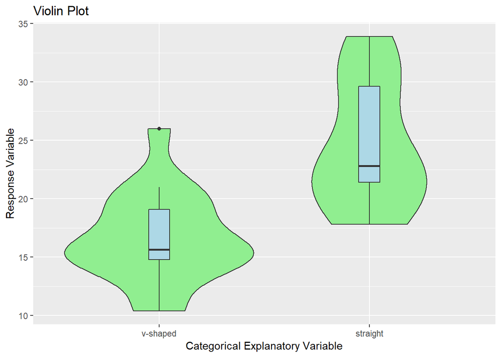

```r
violin_plot(mtcars, "vs", "mpg")
```

### We can estimate a simple model with the type of motor as a predictor of miles per gallon. Once again, this is equivalent to an analysis of variance (ANOVA). This suggests that we have intercept terms in our regression equation and no slopes.

```r
zero_slope <- lm(mpg ~ vs, data = mtcars)
zero_slope %>%  summary()
```

```
##
## Call:
## lm(formula = mpg ~ vs, data = mtcars)
##
## Residuals:
##    Min     1Q Median     3Q    Max
## -6.757 -3.082 -1.267  2.828  9.383
##
## Coefficients:
##             Estimate Std. Error t value Pr(>|t|)
## (Intercept)   16.617      1.080  15.390 8.85e-16 ***
## vsstraight     7.940      1.632   4.864 3.42e-05 ***
## ---
## Signif. codes:  0 '***' 0.001 '**' 0.01 '*' 0.05 '.' 0.1 ' ' 1
##
## Residual standard error: 4.581 on 30 degrees of freedom
## Multiple R-squared:  0.4409, Adjusted R-squared:  0.4223
## F-statistic: 23.66 on 1 and 30 DF,  p-value: 3.416e-05
```

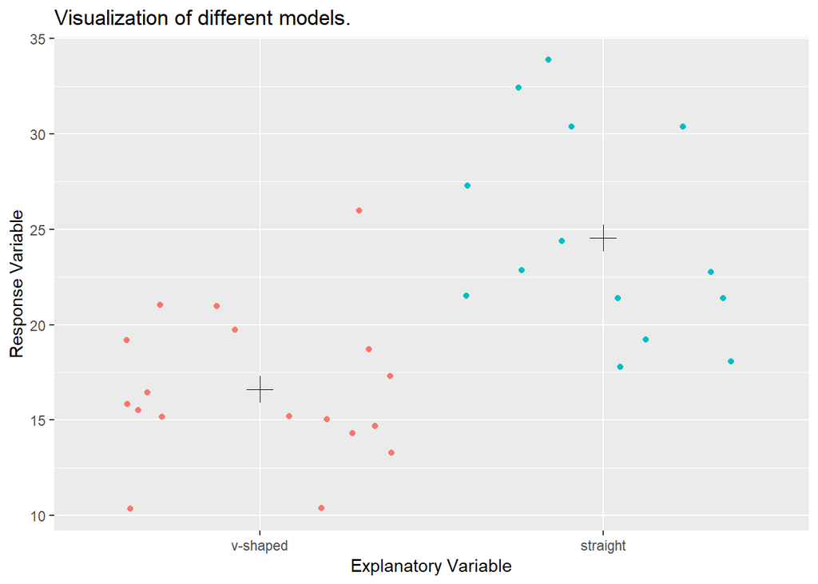

```r
graph_main_effects(mtcars, zero_slope, "vs", "mpg")
```

### Is there a simple linear relationship between mpg and vehicle weight? If so, then we have a good start on creating a model that will help us predict mpg conditional on vehicle weight.

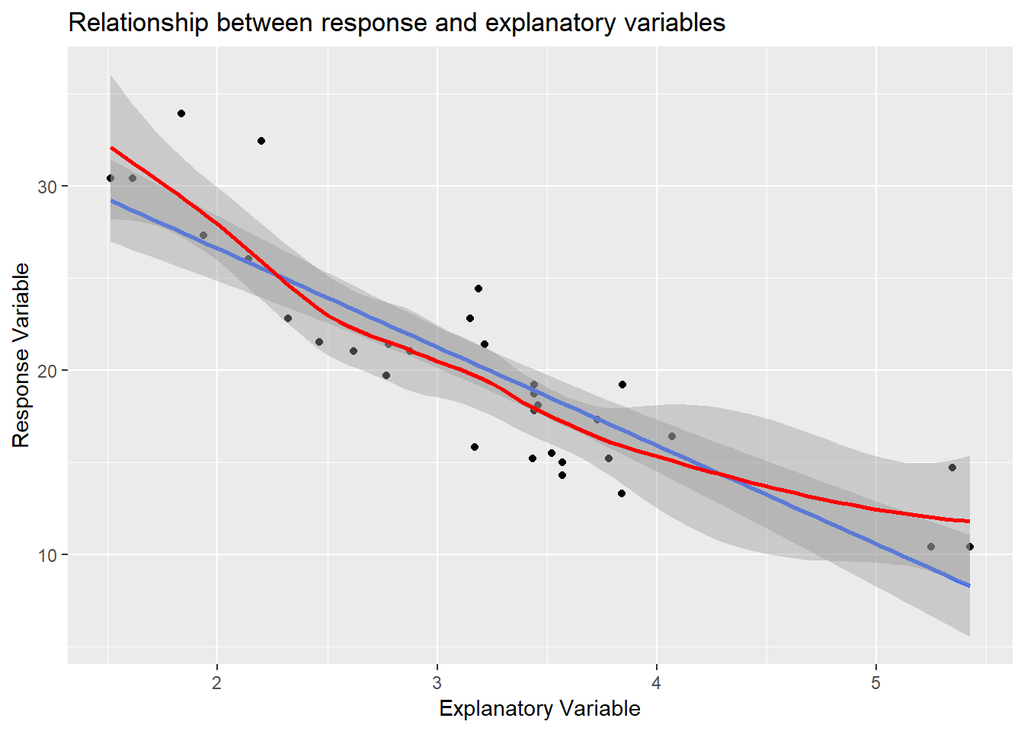

```r
relationship(mtcars, "wt", "mpg")
```

### It is possible to have a common slope for weight and different intercepts based on the type of motor of vehicle. This is one version of an analysis of covariance model.

```r
common_slope <- lm(mpg ~ wt + vs, data = mtcars)
common_slope %>% summary()
```

```
##
## Call:
## lm(formula = mpg ~ wt + vs, data = mtcars)
##
## Residuals:
##     Min      1Q  Median      3Q     Max
## -3.7071 -2.4415 -0.3129  1.4319  6.0156
##
## Coefficients:
##             Estimate Std. Error t value Pr(>|t|)
## (Intercept)  33.0042     2.3554  14.012 1.92e-14 ***
## wt           -4.4428     0.6134  -7.243 5.63e-08 ***
## vsstraight    3.1544     1.1907   2.649   0.0129 *
## ---
## Signif. codes:  0 '***' 0.001 '**' 0.01 '*' 0.05 '.' 0.1 ' ' 1
##
## Residual standard error: 2.78 on 29 degrees of freedom
## Multiple R-squared:  0.801,  Adjusted R-squared:  0.7873
## F-statistic: 58.36 on 2 and 29 DF,  p-value: 6.818e-11
```

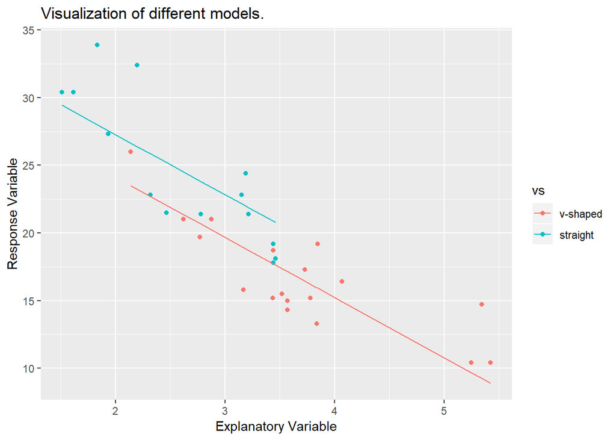

```r
graph_predictions(mtcars, common_slope, "wt", "mpg", "vs")
```

### An analysis of covariance model also allows us to have both categorical and numerical variables as predictors. If we include an interaction term, then each category can have a different slope and intercept.

```r
different_slopes <- lm(mpg ~ wt + vs + wt * vs, data = mtcars)
different_slopes %>% summary()
```

```
##
## Call:
## lm(formula = mpg ~ wt + vs + wt * vs, data = mtcars)
##
## Residuals:
##     Min      1Q  Median      3Q     Max
## -3.9950 -1.7881 -0.3423  1.2935  5.2061
##
## Coefficients:
##               Estimate Std. Error t value Pr(>|t|)
## (Intercept)    29.5314     2.6221  11.263 6.55e-12 ***
## wt             -3.5013     0.6915  -5.063 2.33e-05 ***
## vsstraight     11.7667     3.7638   3.126   0.0041 **
## wt:vsstraight  -2.9097     1.2157  -2.393   0.0236 *
## ---
## Signif. codes:  0 '***' 0.001 '**' 0.01 '*' 0.05 '.' 0.1 ' ' 1
##
## Residual standard error: 2.578 on 28 degrees of freedom
## Multiple R-squared:  0.8348, Adjusted R-squared:  0.8171
## F-statistic: 47.16 on 3 and 28 DF,  p-value: 4.497e-11
```

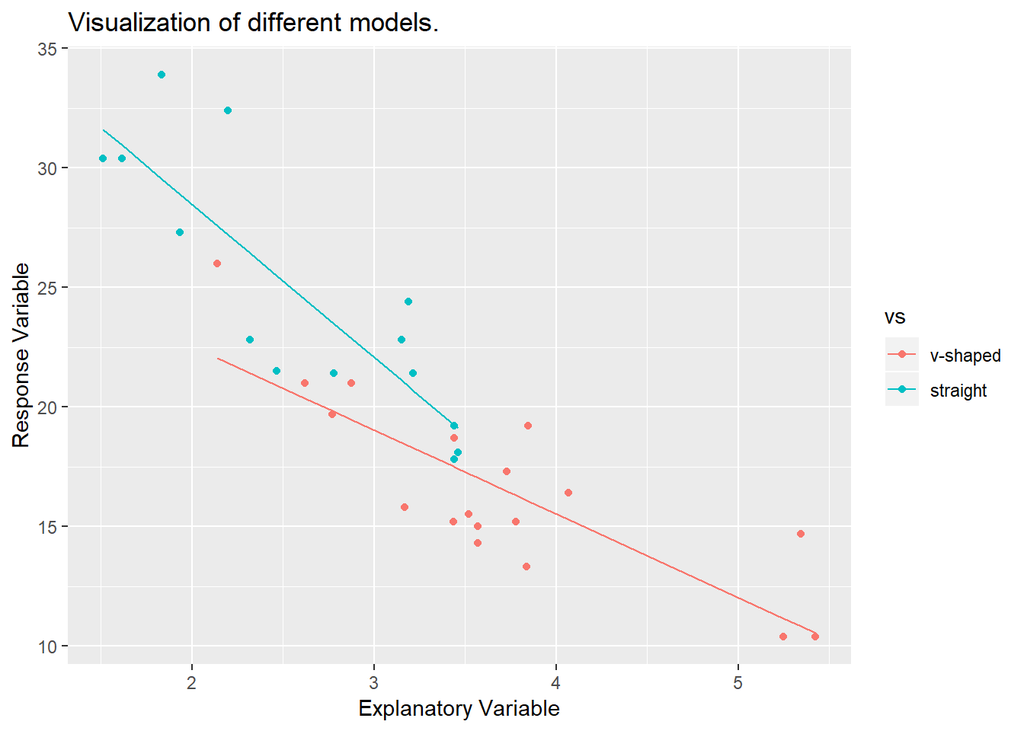

```r
graph_predictions(mtcars, different_slopes, "wt", "mpg", "vs")
```